# t test

Muturi

2024-04-01

### One sample t test

The one-sample t-test is used to determine whether a sample comes from a population with a specific mean. This population mean is not always known, but is sometimes hypothesized.For example Assuming the recruitment data in ideal1.csv is a random sample from a normal distribution - we may wish to test whether the sample mean deviates significantly from the “theoretical mean birth weight of 22kg” among East African zebu cattle

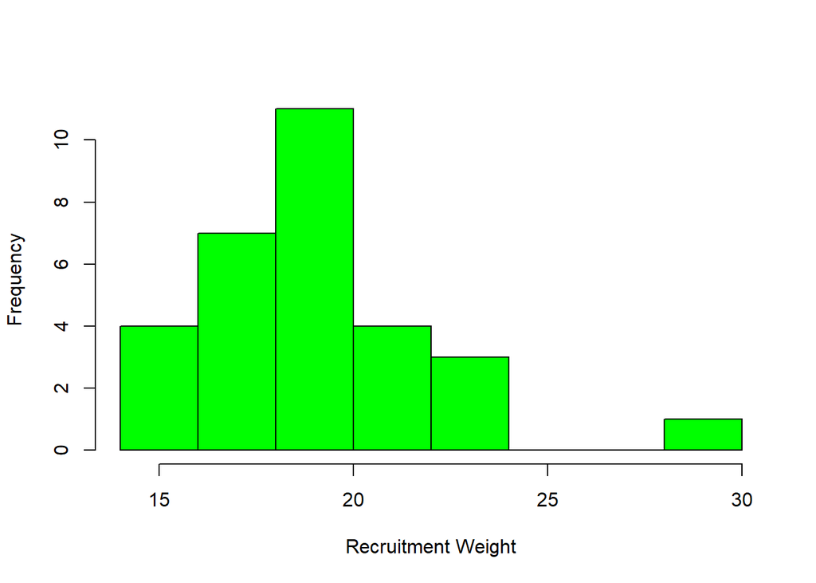

```r
# importing the data sets
ideal1 <- read.csv("https://raw.githubusercontent.com/ThumbiMwangi/R_sources/master/ideal1.csv")
ideal2 <- read.csv("https://raw.githubusercontent.com/ThumbiMwangi/R_sources/master/ideal2.csv")
# Testing for normalitity(first method-visualization)
hist(ideal1$RecruitWeight, xlab="Recruitment Weight", col="green",main="")
```

```r
# Testing for normality (second method-Shapiro-Wilk normality test)
shapiro.test(ideal1$RecruitWeight)
```

```
##
##  Shapiro-Wilk normality test
##
## data:  ideal1$RecruitWeight
## W = 0.9326, p-value = 0.05759
```

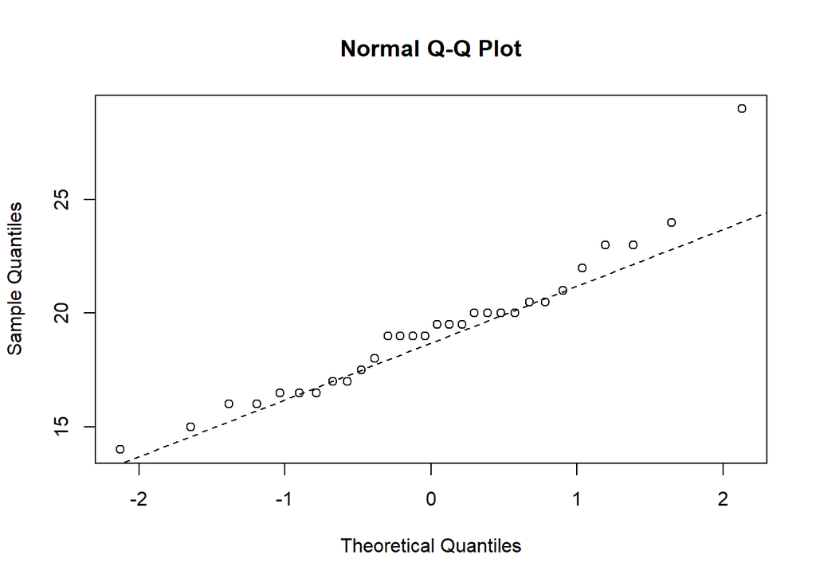

```r
## Testing for normality(q-q plot)
# First, create a qq-plot
qqnorm(ideal1$RecruitWeight)

# Then, add a reference line
qqline(ideal1$RecruitWeight, lty = 2)
```

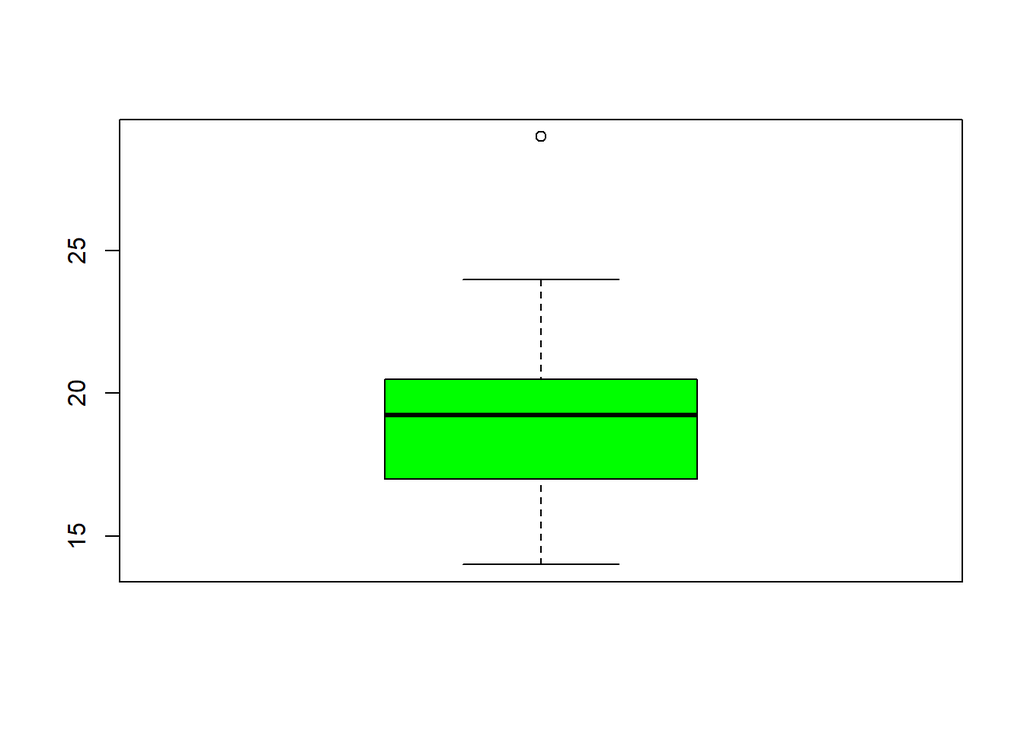

```r
# interpreting Q-Q plot
#Points Aligning on Diagonal Line: If the points on the Q-Q plot align approximately along the diagonal line, it suggests that the data distribution is close to the theoretical distribution (e.g., normal distribution). This indicates a good fit between the data and the theoretical distribution.
#Test for normality is done since t test assumes a normal distribution

#Before making inferences, you want to know if the data is normally distributed, if there are outlier values in the data, and if the values in your data are serially correlated (these scenarios will invalidate inferences made if you use parametric tests such as the Student’s test)

#outliers test (box plot)
boxplot(ideal1$RecruitWeight, col="green")
```

```r
#results(one outlier)

#Understanding the box and whisker plot:

#The darker horizontal line in the boxplot is the median recruitment weight

#The bottom and top of the box is the 25th and 75th percentiles

#The vertical dotted lines are the whiskers and show one of two things:

#The maximum/minimum value of the data

#1.5 times the interquartile range (roughly 2 standard deviations)

#The boxplot tells you location and spread of data, and the skewness (asymmetry of the sizes of upper and lower parts of the box)
#Also a box plot can be used to determine variance for example in cases homogeinity of variance is required.

#An outlier is referred to as a value more than 1.5 times the interquartile range above the 3rd quartile or below the 1st quartile
#watch:https://youtu.be/INSIyaZUXIY?si=J1POfVNF14AY3FPy

# t test
mean(ideal1$RecruitWeight)
```

```
## [1] 19.25
```

```r
t.test(ideal1$RecruitWeight, mu=22)
```

```
##
##  One Sample t-test
##
## data:  ideal1$RecruitWeight
## t = -4.9699, df = 29, p-value = 2.758e-05
## alternative hypothesis: true mean is not equal to 22
## 95 percent confidence interval:
##  18.11831 20.38169
## sample estimates:
## mean of x
##     19.25
```

```r
# results:We reject the null hypothesis - the observed difference between recruitment weight and the recommended is unlikely to occur by chance (small p-value)
```